# Der Effekt von Earnings-Conference Calls am Aktienmarkt

# Motivation

Earnings Conference Calls sind zentrale Informationsereignisse in Finanzmärkten. Hier kommuniziert das Management direkt mit Investoren und Analysten über die aktuelle Geschäftslage und Zukunftsaussichten. Die finanzwirtschaftliche Forschung zeigt, dass diese Calls erhebliche Kursbewegungen auslösen können - doch die zugrundeliegenden Mechanismen sind noch nicht vollständig verstanden.

Während traditionelle Finanztheorie von effizienten Märkten ausgeht, die alle verfügbaren Informationen sofort verarbeiten, zeigen empirische Studien, dass die Art der Kommunikation und das Sentiment der Aussagen eigenständige Erklärungskraft für Aktienkursreaktionen besitzen. Diese Erkenntnisse haben direkte praktische Relevanz: Banken nutzen Sentiment-Analysen für algorithmische Handelsstrategien, Hedge Fonds entwickeln systematische Ansätze zur Textauswertung, und Asset Manager integrieren qualitative Informationen in ihre Bewertungsmodelle.

In diesem Projekt kombinieren Sie Event Studies - eine etablierte Methode der empirischen Finanzforschung zur Messung von Informationseffekten - mit modernen Large Language Models zur systematischen Textanalyse. Sie untersuchen, ob und wie sich qualitative Aussagen des Managements in quantifizierbaren Marktreaktionen niederschlagen, und lernen dabei sowohl die methodischen Grundlagen der Kausalitätsidentifikation als auch den praktischen Umgang mit KI-gestützten Finanzanalysen kennen.

# Event-Study-Methodik und theoretische Diskussion

1. Lesen Sie das Kapitel [“Event Studies” in Huntington-Klein (2021)](https://theeffectbook.net/ch-EventStudies.html) und beantworten Sie die folgenden Fragen dazu:

Kann eine Eventstudie helfen, den kausalen Effekt eines Earnings Conference Calls auf die Aktienrendite eines Unternehmens zu identifizieren? Gehen Sie bei der Beantwortung dieser Frage insbesondere auf die nachfolgenden Punkte ein:

- Welche Art von Variation nutzt eine Eventstudie zur Identifikation des Effekts?
- Welche Voraussetzung(en) müssen erfüllt sein, damit die Eventstudie eine gültige Kausalschätzung liefert?
  - Was bedeutet das “Joint-Test Problem” in diesem Kontext?

Eventstudien können ein nützliches Instrument sein um den kausalen Effekt von Earnings Conference Calls (ECC) zu identifizieren - unter bestimmten Voraussetzungen.  
Im Kontext von ECC bedeutet dies, dass diese klar datiert sein müssen und keine gleichzeitigen Störereignisse erfolgen, wie z.B. Übernahmen oder CEO-Wechsel. Darüberhinaus müssen wir davon ausgehen, dass Aktienmärkte effizient sind und neue Informationen sofort eingepreist werden - also die Effekte des ECC sich sofort abzeichnen. Desweiteren muss bekannt sein wie sich die Aktie entwickelt hätte, wenn kein ECC erfolgt wäre.

Das Problem (Joint-Test) bei einer Eventstudie ist, dass zwangsläufig immer zwei Dinge gleichzeitig getestet werden: Die Wirkung des Events und die Korrektheit des Modells für die erwartete Rendite. Die Veränderung der Rendite kann auf den ECC zurückzuführen sein, aber auch auf ein falsch spezifiziertes Modell.

Wie im Kapitel zu Event Studies von Huntington-Klein (2021) beschrieben, basiert die Identifikation des Event-Effekts auf der Annahme, dass sich im sogenannten „Event Window“ nur das betrachtete Ereignis – hier der Earnings Conference Call – auf die Renditen auswirkt. Die Variation, die genutzt wird, ist somit die zeitliche Veränderung der Rendite eines Unternehmens unmittelbar um das Event-Datum im Vergleich zu einem erwarteten Normalverlauf. Dieser Normalverlauf wird häufig mit Hilfe historischer Daten oder Marktmodellen geschätzt.

Für eine gültige Kausalschätzung müssen laut Huntington-Klein insbesondere zwei zentrale Voraussetzungen erfüllt sein:

1. Keine Confounder im Event Window: Es dürfen keine anderen relevanten Nachrichten oder Ereignisse gleichzeitig mit dem Earnings Call auftreten, die die Renditen beeinflussen könnten.
2. Richtig spezifiziertes Modell: Das zur Schätzung der erwarteten Rendite genutzte Modell (zum Beispiel Marktrendite oder ein multifaktorielles Modell) muss die „normale“ Entwicklung der Aktie korrekt abbilden.

Das „Joint-Test-Problem“ bedeutet dabei, dass die Eventstudie immer gleichzeitig die Gültigkeit des Modells für die erwartete Rendite und die tatsächliche Wirkung des Events prüft. Wenn eine signifikante abnormale Rendite gefunden wird, ist nicht eindeutig, ob dies am Event liegt oder daran, dass das Modell die erwartete Rendite falsch vorhergesagt hat (z.B. weil wichtige Einflussfaktoren fehlen oder Annahmen verletzt sind).

Huntington-Klein betont zudem, dass Eventstudien besonders dann aussagekräftig sind, wenn das Event klar abgrenzbar und der Zeitraum sehr kurz ist – so kann die Wahrscheinlichkeit verringert werden, dass andere Effekte eine Rolle spielen. Zudem empfiehlt er, verschiedene Modelle für die erwartete Rendite zu testen und Robustheitsanalysen durchzuführen, um das Joint-Test-Problem abzumildern.

Insgesamt zeigen Eventstudien, wenn diese methodischen Anforderungen beachtet werden, eine praxisnahe Möglichkeit, kurzfristige kausale Effekte von Informationsereignissen auf Finanzmärkte zu untersuchen. Allerdings bleibt die Interpretation der Ergebnisse immer mit Unsicherheiten behaftet, solange das zugrunde liegende Modell für die erwartete Rendite nicht unabhängig validiert werden kann.

# Daten und Datenaufbereitung

## Finanzmarktkennzahlen

2. Sie sollten in einem ersten Schritt Finanzkennzahlen aus Datastream herunterladen. Insbesondere sollten Sie den Return Index (RI) und die Total Assets (WC02999) für alle Firmen im Euro Stoxx 600 Technology Index ( wir haben Ihnen die RIC Kürzel in der Readme bereitgestellt ) vom 01.01.2020 bis heute extrahieren.

Bitte laden Sie für den Return Index tägliche Daten herunter und für die Total Assets Quartalsdaten. Weiterhin sollten Sie den Total Return Index (RI) des Euro Stoxx 600 (RIC = .STOXX) herunterladen (auch tägliche Daten). Bitte achten Sie darauf alle Daten **in Euro** herunterzuladen.

Achten Sie darauf die RIC als eindeutige Identifikationskennung in ihren Datensatz aufzunehmen.

Das Institut für Finanzwirtschaft der Universität Ulm hat einen ausführlichen [Guide zu Datastream](https://www.uni-ulm.de/fileadmin/website_uni_ulm/allgemein/Update_Introduction_Datastream_May_2025.pdf) erstellt, der Ihnen beim Download der Daten sicherlich helfen kann.

Die Universität Ulm stellt für den Download Remote-PCs zur Verfügung, auf die Sie sich von daheim aus einloggen können. Bitte buchen Sie sich hier einen Slot um Zugriff auf diese PCs zu erhalten: https://www.uni-ulm.de/mawi/iof/lehre/proposals-for-theses/datastream-and-workspace/

Sie sollten ihre Daten in Excel herunterladen und in ihrem Projekt im Unterordner `data` abspeichern.

*Hinweis 1:* Es empfiehlt sich zwei Tabellenblätter im Excel File anzulegen, eines für die täglichen Daten und eines für die Quartalsdaten

*Hinweis 2:* Datastream ist eine Datenbank, die Kennzahlen zur Finanzlage von börsennotierten Unternehmen weltweit beinhaltet. Die Lizenzen zu Datastream an der Universität Ulm werden von der Studienkommission Wirtschaftswissenschaften und der LBBW bezahlt und die Datenbank steht allen WiWi-Studierenden frei zur Verfügung. [Nähere Informationen zu Datastream finden Sie hier](https://www.uni-ulm.de/mawi/iof/lehre/proposals-for-theses/datastream-and-workspace/) (Bitte beachten: Sie müssen im Uninetz (z.B. über VPN) eingeloggt sein um die Informationen zu sehen und um sich auf die Remote-PCs loggen zu können).

*Hinweis 3:* Bei den Total Assets müssen Sie immer das Enddatum des vorherigen Jahres nehmen für den Download, d.h. Start Date wäre 31.12.2019

3. Lesen Sie die Excel Datei, welche Sie in Aufgabe 2 erstellt haben, in R ein. Achten Sie darauf, dass diese Daten tidy und richtig formatiert sind. Joinen Sie die täglichen Daten mit den Quartalsdaten für die relevanten Firmen. Die Quartalsdaten zählen für das komplette Quartal zu dem diese hinzugemerged wurden.

Setzen Sie sich mit den Aktienkursen auseinander und beantworten folgende Fragen: - Sie wollen in Aufgabe 4 *Renditen* berechnen, warum sollten Sie Daten zum “Total Return Index” und nicht dem “Price” oder “Unadjusted Price” herunterladen? Schauen Sie sich zur Klärung dieser Frage den [Guide der Uni Ulm zu Datastream](https://www.uni-ulm.de/fileadmin/website_uni_ulm/allgemein/Update_Introduction_Datastream_May_2025.pdf) genauer an. Diesen Guide sollten sie auch für den Download der Daten heranziehen.

*Hinweis:* In dem tidy Datensatz sollten Sie eine Spalte mit dem Unternehmensidentifier (RIC), eine mit dem Datum und eine mit der Variablen (RI bzw. Total Assets) haben

**Sie wollen in Aufgabe 4 *Renditen* berechnen, warum sollten Sie Daten zum “Total Return Index” und nicht dem “Price” oder “Unadjusted Price” herunterladen?**

Um realistische und vollständige Renditen zu berechnen, sollten Daten zum Total Return Index (RI) verwendet werden, da dieser nicht nur die reine Kursentwicklung, sondern auch ausgeschüttete Dividenden und Kapitalmaßnahmen wie Aktiensplits berücksichtigt. Im Gegensatz dazu geben die Preisdaten (Price oder Unadjusted Price) lediglich den Börsenkurs wieder, ohne Erträge aus Dividenden zu erfassen. Da Dividenden ein wesentlicher Bestandteil der Gesamtrendite eines Investments sind, würde eine Renditenberechnung auf Basis von Preisdaten die tatsächliche Performance systematisch unterschätzen. Daher ist der Total Return Index die geeignetste Kennzahl für Event-Studien, die auf eine präzise Erfassung von Marktreaktionen abzielen.

## Renditen berechnen

4. In ihrem Datastream-Datensatz, welchen Sie in Aufgabe 2 bereits eingelesen und in Aufgabe 3 bearbeitet haben, sind die *Total Return Indices* (RI) der größten Unternehmen aus der Tech-Branche in Europa enthalten, sowie der *Total Return Indix* des Euro Stoxx 600. Der Euro Stoxx 600 ist ein großer, diversifizierter Aktienindex in Europa in dem die 600 größten Unternehmen gelistet sind. Sie sollten den Euro Stoxx 600 als Benchmark ( Rendite des Marktes ) für ihre betrachteten Unternehmen verwenden. Bitte berechnen Sie in dieser Aufgabe die Tagesrenditen aller Einzelunternehmen als:

$$\begin{equation}
Rendite_{i,t} = \frac{RI_{i,t} - RI_{i,t-1}}{RI_{i,t-1}}
\end{equation}$$

mit i = {jedes Einzelunternehmen im Datensatz} und t = {Tag}

und des Euro Stoxx 600 als:

$$\begin{equation}
Rendite_{m,t} = \frac{RI_{m,t} - RI_{m,t-1}}{RI_{m,t-1}}
\end{equation}$$

mit m = {Euro Stoxx 600} und t = {Tag}

Prüfen Sie auf NA in den Anfangszeilen und entfernen Sie diese.

Speichern Sie die Renditen der jeweiligen Unternehmen in einer neuen Variable `Rendite` ab und die Rendite des Euro Stoxx 600 als `Marktrendite`.

5. In Aufgabe 1 hatten Sie sich bereits mit der Event-Study Methodik beschäftigt, welche Sie im weiteren Verlauf des Projektes anwenden sollen. Ein erster Schritt ist es, sogenannte *Abnormale Renditen* zu berechnen. Dies sollten Sie in dieser Aufgabe mit dem sogenannten Market-adjusted returns model tun. Bitte ziehen Sie dafür die Rendite des Marktindex von der Rendite des einzelnen Unternehmens pro Tag ab.

$$\begin{equation}
AbnormaleRendite_t = Rendite_{i,t} - Rendite_{m,t}
\end{equation}$$

Beantworten Sie dazu folgende Frage:

- Warum ist es nötig die Marktrendite ( $Rendite_{m,t}$ ) von der Rendite der Einzelaktien abzuziehen? Nutzen Sie ihre Erkenntnisse aus Aufgabe 1 zur Beantwortung dieser Frage.

Die Marktrendite stellt die durchschnittliche Entwicklung des Markts an einem bestimmten Tag dar **unabhängig von einem bestimmten Unternehmen**. Die **anbormale Rendite** zeigt ob ein Unternehmen besser oder schlechter abgeschnitten hat, als der Markt insgesamt.

## Earnings Call-Transkripte von LSEG Workspace einlesen

Die Basis für alle weiteren Analysen sind die Abnormalen Renditen der einzelner Unternehmen, die Sie in den vorherigen Aufgaben berechnet haben. Jedoch benötigen Sie nun noch ein Event, dessen Effekt Sie im Rahmen der Eventstudie analysieren möchten. Hier kommen die bereits in der Motivation erwähnten Earnings-Conference-Calls ins Spiel, die Sie im weiteren Verlauf des Projekts näher analysieren sollten. Die Earnings Conference Calls finden für große Unternehmen in der Regel quartalsweise statt. Manche Unternehmen halten jedoch auch nur halbjährliche Earnings Conference Calls ab und andere verzichten ganz darauf.

6. Wir haben Ihnen die Earnings Conference Calls aus LSEG Workspace für alle Firmen aus dem Euro Stoxx 600 Technology Sektor ab 2020 bis zum aktuellen Rand heruntergeladen und diese unter `data/transcripts.zip` bereitgestellt. Lesen Sie die Dateien in R ein. Ihr Datensatz sollte für jedes Transkript das RIC-Kürzel, Datum und den Text des Transkripts beinhalten, dies können Sie aus dem Namen der Datei extrahieren.

*Hinweis:* Das RIC Kürzel finden Sie im Namen der Datei (Beispiel: “2020-Jan-28-SAPG.DE-140242583050-Transcript.txt” -> “Datum-RIC-Nummer-Transcript.txt”)

Die Earnings Conference Calls laufen immer gleich ab: Zuerst spricht der CEO und meist CFO über die aktuellen Entwicklungen am Markt und wie das Unternehmen aktuell steht. Weiterhin werden Einschätzungen für die Zukunft angesprochen. Im zweiten Teil, der Q&A Sektion, dürfen Analysten Fragen an das Management stellen. Dieser Teil ist meist informativer als die vorbereiteten Statements des Managements, da die Fragen nicht vorher abgesprochen werden und das Management spontane Antworten bereithalten muss.

Sie sollen sich in diesem Projekt auf den zweiten Teil, d.h. die Q&A Section in den Earnings Conference Calls konzentrieren.

7. Analysieren Sie im ersten Schritt die Earnings Conference Calls indem Sie einige davon überfliegen. Schauen Sie explizit nach Hinweisen, ob und wie die Q&A Sektion im Text von den anderen Inhalten abgetrennt ist. Anschließend sollten Sie diese Q&A Sektion in den Earnings Conference Calls in R extrahieren, da Sie nur diese Sektion in den späteren Aufgaben analysieren sollen.

Da es vorteilhaft für ihre weitergehenden Analysen ist möglichst kompakte Texte ohne Redundanzen zu haben, sollten Sie zusätzlich die Definitionen und Disclaimer Sektion am Ende des Earnings Calls entfernen.

*Hinweis 1:* Der Anteil der Q&A Sektion an der Gesamtkonversation liegt in der Regel unter 80%. Für manche Earnings Conference Calls ist dieser Anteil höher, aber hier würde ich empfehlen nachzuschauen, ob Sie die Q&A Sektion richtig extrahiert haben. Manchmal gibt es keine Q&A Sektion, dann sollte dort auch kein Text extrahiert werden.

*Hinweis 2:* Nutzen Sie das Paket `stringr` um Textmanipulationen vorzunehmen. In diesem [Cheatsheet](https://rstudio.github.io/cheatsheets/strings.pdf) sehen Sie die Hauptanwendungen inkl. regulärer Ausdrücke, welche wichtig sind um mit Texten zu arbeiten.

8. Stellen Sie in einer Grafik anschaulich dar, wie viele Worte in einem typischen Earnings Conference Call verwendet werden und wie viel davon die Q&A Sektion einnimmt.

Beschreiben Sie ihre Grafik.

*Hinweis:* Eventuell wollen Sie hier die Verteilungen zeigen o.ä.? Entscheiden Sie selbst, welche Grafik Sie produzieren.

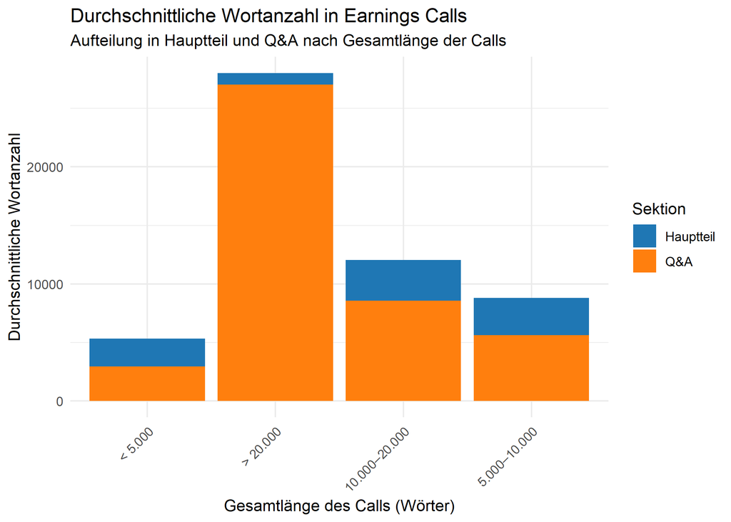

**Beschreibung:**  
Das dargestellter Balkendiagramm zeigt die durchschnittliche Wortanzahl in Earning Calls, aufgeteilt in Hauptteil und Q&A. Dabei wird auf der x-Achse die Gesamtlänge der Calls (in Wörter) angegeben. Auf der y-Achse befindet sich die durchschnittliche Wortzahl. Die Balken sind aufgteilt in Hauptteil und Q&A-Teil. Aus der Legende rechts des Diagramms lässt sich entnehmen, dass der Hauptteil blau und der Q&A-Teil orange gefärbt ist.  
Die Grafik besteht aus 4 Balken. Ein Balken für Calls unter einer Gesamtlänge von 5000 Wörter, einer für über 20000, einer für eine 10000-20000 Wörter und einen für eine Gesamtlänge von 5000-10000 Wörter.  
Der Grafik ist zu entnehmen, dass der Hauptteil meistens eine Länge von ca. 2500-3500 Wörter einnimmt. Nur bei Calls von einer Gesamtlänge von über 20000 Wörter ist der Hauptteil deutlich kleiner und liegt bei ca. 1000 Wörter.  
Der Q&A-Teil ist also der ausschlaggebende Faktor bei der Gesamtlänge der Calls.

## Themenkategorien und Sentiment-Scores

Nachdem Sie nun die Earnings Conference Calls in R eingelesen und einen ersten Eindruck von deren Inhalt erhalten haben sollten Sie diese mit einem LLM (konkret mit Google Gemini) analysieren. Dafür sollten Sie einen Zero-Shot Prompt erstellen und mit Hilfe dieses Prompts die Aussage der Q&A Sektionen der Earnings Conference Calls analysieren.

9. Entwickeln Sie einen Zero-Shot Prompt für ein Large Language Model (LLM), der Earnings Conference Call Transcripts analysiert und strukturierte Sentiment-Bewertungen ausgibt. Bitte beachten Sie dabei folgende Punkte:

Zielkategorien:

- Unternehmensperformance (Finanzlage, Wachstumschancen, Unternehmensrisiken)
- Marktumfeld (Branche, Wettbewerb, externe Faktoren)

Output-Format:

- JSON-Struktur mit Sentiment-Scores von -1 (sehr negativ) bis +1 (sehr positiv)
- Keine zusätzlichen Erklärungen oder Markdown-Formatierung

Sie sollten in ihrem Prompt nach einem JSON Output verlangen (strukturiertes Format), welchen Sie mit dem Paket `jsonlite` gut in R verarbeiten können.

*Hinweis 1:* Im Anhang ist eine Erklärung für die Unterschiede zwischen einem Zero-Shot Prompt, einem One-Shot Prompt und einem Few-Shot Prompt

*Hinweis 2:* Wir haben Ihnen ein [Tutorial zusammengestellt](https://projektkurs-data-science-ulm2425.netlify.app/tutorials/zero-prompting), welches das Prompting an einem Beispiel zeigt.

*Unser Prompt:*

Du erhältst die Q&A-Sektion eines Earnings Conference Calls. Analysiere die Texte und bewerte das **Sentiment** in den folgenden zwei Zielkategorien getrennt voneinander:

1. Unternehmensperformance (inkl. Finanzlage, Wachstumschancen, Unternehmensrisiken)
2. Marktumfeld (inkl. Branche, Wettbewerb, externe Faktoren)

Gib das Ergebnis ausschließlich als JSON-Objekt zurück. Verwende für jede Kategorie einen Sentiment-Wert zwischen -1 (sehr negativ) und +1 (sehr positiv). Füge **keine** zusätzlichen Erklärungen oder Formatierungen hinzu.

10. Im nächsten Schritt sollten Sie sich in das Paket [`ellmer`](https://ellmer.tidyverse.org/) einarbeiten. Durch `ellmer` erhalten Sie Zugriff auf alle gängigen LLMs mittels R über einen API Zugang. Wir haben ihnen für dieses Projekt ein Google Konto pro Gruppe erstellt und den API Schlüssel für jede Gruppe in das dazugehörige Repo (Readme) gepushed.
- Lesen Sie sich in das [`ellmer`](https://ellmer.tidyverse.org/) Paket ein und wie Sie den API Schlüssel für Google Gemini in ihrer .Renviron Datei hinterlegen können
- Untersuchen Sie die unterschiedlichen Modelle, die Google zur Verfügung stellt und deren Ratelimits: https://ai.google.dev/gemini-api/docs/models?hl=de

Bitte beantworten Sie folgende Fragen:

- Was sind die Vorteile/Nachteile der einzelnen Google Modelle?
- Welches (kostenlose) Modell würden Sie für ihre aktuellen Analysen bevorzugt einsetzen? Begründen Sie!
- Welche Möglichkeiten haben Sie, nicht in die Ratelimits zu kommen?
- In `ellmer` können Sie mittels dem [`params()`](https://www.tidyverse.org/blog/2025/05/ellmer-0-2-0/#parameters) Parameter auch die Temperatur ihres Modells einstellen. Was ist mit der Temperatur gemeint und was sind die Vorteile/Nachteile einer niedrigen Temperatur?

Google stellt insgesamt **3 Modelle** seiner KI Gemini zur Verfügung:

**1. 2.5 Pro**

**2. 2.5 Flash**

**3. 2.5 Flash-Lite**

Es existieren zu diesen Modellen noch teilweise Untermodelle, welche zusätzliche Features bieten, wie bspw. die Ausgabe von Audiodateien.

Die Modelle unterscheiden sich dazu auch in Anfragen pro Minute **(RPM)**, Anfragen Pro Tag **(RPD)** und Tokens pro Miunte **(TPM)**. Die nachfolgende Tabelle zeigt hier die Limits je nach Stufe an (Stand 03.07.2025).

| Modell | RPM | TPM | RPD |
| --- | --- | --- | --- |
| Gemini 2.5 Pro | 5 | 250.000 | 100 |
| Gemini 2.5 Flash | 10 | 250.000 | 250 |
| Gemini 2.5 Flash-Lite Preview 06-17 | 15 | 250.000 | 1.000 |

**2.5 Pro**

**2.5 Flash**

Bei diesem Modell handelt es sich um eine leicht schwächere Version des Pro-Modells, welche jedoch alle wesentlichen Funktionen beinhaltet. Bei Bedarf denkt das Modell nach und es können Budgets für Denkprozesse individuell konfiguriert werden. Es eignet sich am besten für Aufgaben mit niedriger Latenz und hohem Volumen

**2.5 Flash-Lite**

Das *Flash-lite-Modell* ist das günstigste Modell. Dementsprechend ist es am leistungsschwächsten von allen Modellen. Derzeit ist nur die Preview dieser Version verfügbar.

**Was ist die Temperatur im Paket `ellmer` in R?**

Die Temperatur ist ein gängiges Konzept bei Sprachmodellen. Mittels der Temperatur lässt sich die Kreativität bzw. Zufälligkeit der Textgenerierung steuern. Die Temperatur nimmt Werte im Intervall zwischen 0 und 1 an. Manche Modellen können jedoch Temperaturen von über 1 annehmen, wie beispielsweise ChatGPT oder auch Google Gemini.

Die Antworten eines LLMs bei niedrigeren Temperaturen sind i.d.R. konsistenter und weniger fehleranfällig. Dabei können Antworten aber auch starr und langweilig wirken. Die Variation ist bei einer niedrigen Temperatur auch eher eingeschränkt. Desweiteren können Modelle hierbei auch Schwierigkeiten aufzeigen bei kreative und offenen Aufgaben. In solchen Fällen empfiehlt es sich die Temperatur höher zu wählen.

11. Nutzen Sie ihren in Aufgabe 9 erstellten Prompt mit dem `ellmer` Paket und ihrem Google API-Key um alle 431 Earnings Conference Call Transkripte zu analysieren. Nutzen Sie für ihre Analyse das Modell Google Gemini 2.0-flash oder Google Gemini 2.5-flash.

Speichern Sie die Ergebnisse ihrer Analyse in einem strukturierten Tibble ab. Anschließend sollten Sie den Datensatz auch unter `data/sentiment.Rds` abspeichern.

Stellen Sie ihre Ergebnisse in einer Tabelle dar und beschreiben diese kurz:

- Wie ist der Mittelwert, Standardabweichung und Median der Einschätzung bezüglich Unternehmensperformance und Marktumfeld in ihren Earnings Conference Calls?

*Hinweis 1:* Achten Sie darauf nicht bei jedem Knitten die Analyse neu zu starten, sondern setzen Sie den Chunk dieser Aufgabe auf `eval = FALSE` und lassen Sie die Analyse nur einmal durchlaufen und speichern Sie die Ergebnisse ab (und laden diese später um damit weiterarbeiten zu können)

*Hinweis 2:* Achten Sie auf ihre Ratelimits und beanspruchen Sie den API Zugriff nicht zu stark, z.B. durch den Einbau von “sleep”-Zeiten in ihrem Code

| Kennzahl | Mittelwert | Standardabweichung | Median |
| --- | --- | --- | --- |
| Marktumfeld | 0.41 | 0.37 | 0.6 |
| Unternehmensperformance | 0.69 | 0.33 | 0.8 |

Unternehmensperformance: Mit einem Mittelwert von 0.69 wird die eigene Performance insgesamt positiv bewertet. Die Standardabweichung beträgt 0.33, was auf eine etwas geringere Streuung als beim Marktumfeld hindeutet. Der Median liegt bei 0.80, was bedeutet, dass mehr als die Hälfte der Unternehmen ihre Performance sehr positiv einschätzen. Auch hier deutet die Differenz zwischen Median und Mittelwert auf eine leichte Schiefe in der Verteilung hin.

Sie haben in der vorherigen Aufgabe die Stimmung bezüglich der Kategorien Unternehmensperformance und Marktperformance in den Earnings Conference Calls bestimmt. Eine Frage wäre, ob sich diese Stimmung über die Zeit hinweg verändert hat. In der folgenden Aufgabe sollen Sie sich die durchschnittliche Stimmung in diesen zwei Kategorien für die einzelnen Jahre in ihrem Datensatz näher anschauen.

12. Erstellen Sie eine geeignete Grafik um die Stimmung *aller Earnings Conference Calls eines Jahres* zu visualisieren. Tragen Sie separat die Stimmung bezüglich Unternehmensperformance und Marktumfeld ab.

Beschreiben Sie ihre Grafik.

Interpretieren Sie diese Grafik, insbesondere im Hinblick auf die gesamtwirtschaftlichen Ereignisse der letzten fünf Jahre. Hätten Sie die Ergebnisse in dieser Art erwartet?

*Hinweis:* Sie sollten sich hier eine sinnvolle Grafik überlegen, welche die Stimmungslage über die Zeit gut darstellt.

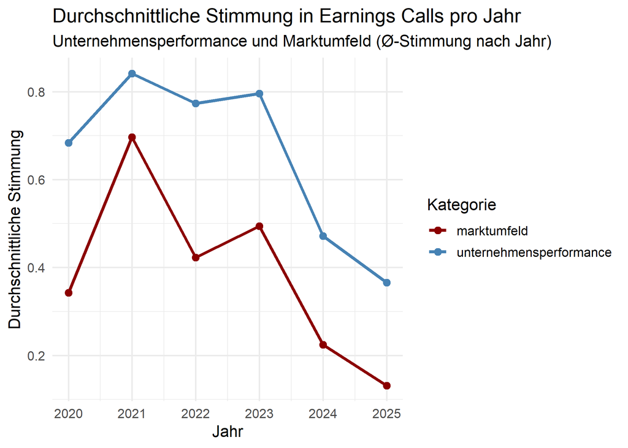

# Eventstudie

Um zu evaluieren, ob die Earnings Conference Calls tatsächlich einen Einfluss auf die Aktienkurse der einzelnen Unternehmen hatten können Sie eine sogenannte Eventstudie durchführen, welche Sie bereits in Aufgabe 1 kennen gelernt haben. Bei einer Eventstudie betrachten Sie nur die Zeit (bei uns die Tage) unmittelbar vor oder nach einem Event. In diesem Projekt ist ein Event ein Earnings Conference Call des jeweiligen Unternehmens. Sie sollen in diesem Projekt herausfinden, wie sich über alle Unternehmen hinweg die Earnings Conference Calls auf die Aktienrenditen auswirken.

13. Verbinden Sie den Datensatz über die *Stimmung der Earnings Conference Calls (sentiment.Rds)* zu den einzelnen Unternehmen mit den *abnormalen Renditen* und speichern diesen Datensatz als `gesamtdatensatz` in R ab. Sie können das RIC-Kürzel und Datum für den Join verwenden. Sollte der Earnings Conference Call an keinem Handelstag stattgefunden haben, so joinen Sie bitte mit dem darauffolgenden Handelstag.
- Für die Tage an denen ein Earnings Conference Call stattgefunden hat sollten Sie eine Variable `event` generieren, welche an dem Tag des Calls gleich 0 ist.
- Für die Tage vor dem Earnings Conference Call (Event) sollte die Variable `event` rückwärts zählen (bis zu -5). Für alle Tage nach dem Event sollte die Variable `event` fortgeführt werden (bis +5).
- Erstellen Sie eine Variable `ar_505`, welche die *abnormalen Rendite* von Tag -5 bis +5 **fortlaufend** aufsummiert
- Erstellen Sie eine Variable `car_101`, welche die kumulierte abnormale Rendite im Zeitraum -1 bis +1 um das Event beinhaltet
- Erstellen Sie weiterhin diese sechs neuen Variablen:
  - `negativ_firm` = Wenn die Unternehmensperformance als negativ eingeschätzt wird
  - `neutral_firm` = Wenn die Unternehmensperformance als neutral eingeschätzt wird
  - `positiv_firm` = Wenn die Unternehmensperformance als positiv eingeschätzt wird
  - `negativ_market` = Wenn die Marktperformance als negativ eingeschätzt wird
  - `neutral_market` = Wenn die Marktperformance als neutral eingeschätzt wird
  - `positiv_market` = Wenn die Marktperformance als positiv eingeschätzt wird
- Erstellen Sie Dummy Variablen, die 1 sind für ein bestimmtes Jahr. Bspw. eine Dummyvariable die 2020 heißt und für alle Beobachtungen im Jahr 2020 sollte diese Variable 1 sein, 0 sonst. Tun Sie dies für alle Jahre in ihrem Datensatz

*Hinweis:* Die Funktion cumsum() könnte für diese Aufgabe hilfreich sein

14. Erstellen Sie je ein Liniendiagramm für die von ihnen betrachteten Unternehmen: Eines für die Stimmung bezüglich der Unternehmensperformance und eines bezüglich der Marktperformance.

Sie sollten in ihren Grafiken die kumulierten Renditen im Zeitraum [-5,5] Tage um einen Earnings Conference Call darstellen. - Die Variable “Event” sollte die Tage vor und nach dem Earnings Conference Call enthalten ([-5,5]) und auf der x-Achse dargestellt werden - Die Variable `ar_505` sollte die durchschnittliche kumulierte abnormale Rendite für den jeweiligen Tag auf der y-Achse abtragen (für alle Unternehmen in ihrem Datensatz) - In jeder Grafik sollten Sie eine extra Linie zeichnen für Earnings Conference Calls mit einer positiven/negativen und neutralen Stimmung und deren Einfluss auf den Aktienmarkt

Beschreiben und interpretieren Sie ihre Grafik. Gehen Sie hierbei insbesondere darauf ein, welche Erwartungen Sie auf der Basis ihrer Lektüre aus Aufgabe 1 hatten und in wie weit diese Erwartungen sich erfüllt haben.

*Hinweis:* In diesen Grafiken stellen Sie nicht jedes Event (d.h. die Auswirkungen eines jeden Earnings Conference Calls) einzeln dar, sondern gesamt für alle Earnings Conference Calls.

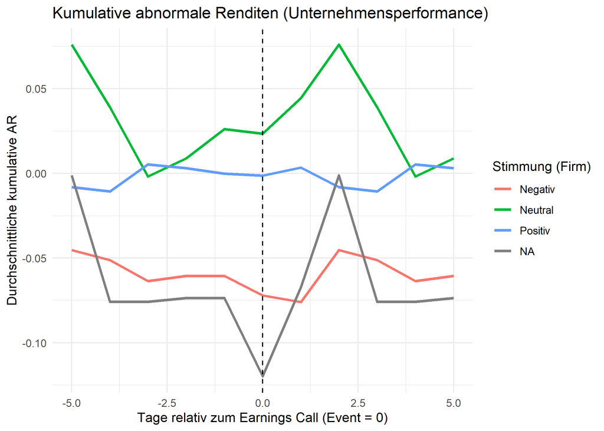

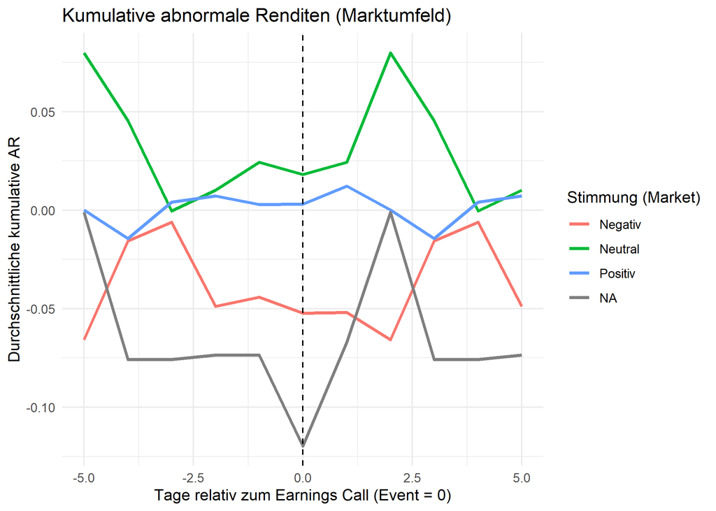

Insgesamt stützen die Ergebnisse die Annahme, dass Earnings Conference Calls kausale Effekte auf die Aktienrenditen haben können, sofern die methodischen Voraussetzungen erfüllt sind – insbesondere die Abwesenheit anderer gleichzeitiger Ereignisse und ein korrekt spezifiziertes Modell für die erwartete Rendite. Besonders die klare Differenzierung der Renditeverläufe nach Stimmung unterstreicht die Aussagekraft der Eventstudienmethode in diesem Kontext

# Regressionen

Sie haben bisher den Einfluss der Earnings Conference Calls auf die Aktienrendite der größten europäischen Unternehmen im Technologie-Sektor visuell betrachtet. Im letzten Abschnitt dieser Projektarbeit analysieren Sie ihre Daten mittels linearer Regressionen.

15. In dieser Aufgabe sollten Sie zwei Regressionen erstellen:

Regressieren Sie die kumulierten abnormalen Renditen um das Event `car_101` auf die Dummyvariablen

- `negativ_firm` und `negativ_market` in der ersten Regression und
- `positiv_firm` und `positiv_market` in der zweiten Regression.

Diese Dummyvariablen geben die Stimmung in den Earnings-Conference Calls wieder.

Beschreibung und interpretieren Sie ihre Regressionsergebnisse und gehen Sie dabei auch auf folgende Fragen ein:

- Was ist die Vergleichsgruppe in den beiden Regressionen?
- Was sind die Voraussetzungen für eine kausale Interpretation der Koeffizienten. Sind diese ihrer Meinung nach gegeben?

|  | Negative Stimmung | Positive Stimmung |
| --- | --- | --- |
| Negativer Firmensentiment | -0.090*** |  |
|  | (0.019) |  |
| Negativer Marktsentiment | 0.043*** |  |
|  | (0.010) |  |
| Positiver Firmensentiment |  | 0.031** |
|  |  | (0.011) |
| Positiver Marktsentiment |  | -0.053*** |
|  |  | (0.009) |
| Num.Obs. | 2542 | 2542 |
| R2 | 0.011 | 0.016 |
| R2 Adj. | 0.010 | 0.015 |
| F | 13.610 | 20.281 |

+ p < 0.1, * p < 0.05, ** p < 0.01, *** p < 0.001

**Beschreibung**

Die abgebildete Tabelle zeigt die Ergebnisse zweier linearer Regressionen, in denen untersucht wurde, wie sich verschiedene Sentiment-Indikatoren auf die kumulierten abnormalen Renditen (`car_101`) im Zeitraum von drei Tagen um einen Earnings Conference Call auswirken. Die Tabelle ist in zwei Spalten unterteilt: „Negative Stimmung“ und „Positive Stimmung“. Jeweils werden Dummy-Variablen verwendet, um den Einfluss von negativem bzw. positivem Sentiment auf Unternehmens- und Marktebene zu erfassen.

Für die Regression mit negativer Stimmung ergibt sich, dass ein negativer Firmensentiment-Koeffizient von -0.090 (Standardfehler 0.019) signifikant ist (p < 0.001), was auf einen klar negativen Zusammenhang zwischen negativer Stimmung auf Unternehmensebene und den abnormalen Renditen hindeutet. Negatives Marktsentiment hat dagegen einen positiven und ebenfalls hoch signifikanten Koeffizienten von 0.043 (SE = 0.010). In der Regression mit positiver Stimmung zeigt sich, dass ein positiver Firmensentiment-Koeffizient von 0.031 (SE = 0.011, p < 0.01) die Renditen leicht positiv beeinflusst, während positives Marktsentiment einen negativen Effekt von -0.053 (SE = 0.009, p < 0.001) hat. Die erklärten Varianzen (R²) sind in beiden Modellen relativ niedrig (0.011 bzw. 0.016), was darauf hindeutet, dass die Sentiment-Variablen nur einen kleinen Teil der Variation in den abnormalen Renditen erklären.

**Analyse**

Die Ergebnisse lassen darauf schließen, dass das Sentiment, insbesondere auf Firmenebene, einen messbaren Einfluss auf die Aktienkursreaktionen rund um Earnings Conference Calls hat. Negatives Sentiment wird am Markt klar abgestraft, während positive Stimmung mit leicht erhöhten Renditen belohnt wird – allerdings sind die Effekte nicht symmetrisch stark ausgeprägt. Auffällig ist, dass negatives Marktsentiment im Modell für negative Stimmung sogar positiv mit den Renditen korreliert, während positives Marktsentiment im Modell für positive Stimmung negativ wirkt. Das könnte auf Wechselwirkungen oder mögliche Überschneidungen in der Wahrnehmung von Markt- und Firmensentiment hindeuten.

Die Vergleichsgruppe in beiden Regressionen sind die Ereignisse, bei denen sowohl die Firmensentiment- als auch die Marktsentiment-Dummyvariablen den Wert 0 haben – also „neutrale“ Stimmung oder kein ausgeprägtes Sentiment. Alle Effekte sind daher im Vergleich zu dieser neutralen Referenz zu interpretieren.

Für eine kausale Interpretation der Koeffizienten müssten mehrere Voraussetzungen erfüllt sein: Es darf keine unbeobachtete Heterogenität oder Störfaktoren geben, die sowohl das Sentiment als auch die Renditen beeinflussen (kein omitted variable bias). Außerdem müsste sichergestellt sein, dass das Sentiment tatsächlich vor und nicht als Reaktion auf Kursbewegungen bestimmt wurde (keine Reverse Causality). Da in Eventstudien wie hier die Events zufällig verteilt und die Märkte effizient sind, können die Voraussetzungen näherungsweise gegeben sein – aber Unsicherheiten bleiben, z. B. durch mögliche andere News rund um das Event. Insgesamt zeigen die Ergebnisse einen plausiblen Zusammenhang, der aber mit Vorsicht zu interpretieren ist.

16. In ihrer deskriptiven Analyse haben Sie bereits gesehen, dass die Unternehmen, die Sie in diesem Projekt betrachten, alle unterschiedlich groß sind. Weiterhin haben Sie gesehen, dass es ein unterschiedliches Stimmungsbild in den Calls über die einzelnen Jahre hinweg gibt. Dafür möchten Sie in ihren Regressionen nun kontrollieren.
    1. Regressieren Sie die `car_101` auf die Variablen *negativ_firm* und *negativ_market* und kontrollieren Sie auf die Größe des jeweiligen Unternehmens, indem Sie die Variable *Total_Assets* in ihre Regression aufnehmen
    2. Fügen Sie in einer zweiten Analyse zusätzlich zu den Variablen aus der 1. Regression auch noch Dummyvariablen für die Jahre in dem das Event stattgefunden hat ihrer Regression hinzu.
    3. Führen Sie die Regressionen aus 1. und 2. auch für die Variablen *positiv_firm* und *positiv_market* anstatt *negativ_firm* und *negativ_market* durch, sodass Sie am Ende 4 Regressionen haben

Beschreiben und interpretieren Sie ihre Ergebnisse im Hinblick auf die Größe der Koeffizienten und deren Signifikanz. Gehen Sie insbesondere auf folgende Fragen ein:

- Warum sollte ihre Regression nicht fünf Dummyvariablen, je eine für jedes Jahr, sondern nur vier beinhalten?
- Verändert sich durch die Dummyvariablen der Koeffizient von *negativ_firm* und *negativ_market* bzw. *positiv_firm* und *positiv_market*?
- Hätten Sie eine Veränderung des Koeffizienten von *negativ_firm*, *negativ_market*, *positiv_firm* oder *positiv_market* erwartet? Begründen Sie ihre Antwort mit ihren deskriptiven Analysen.

|  | Negativ ohne Jahr | Negativ mit Jahr | Positiv ohne Jahr | Positiv mit Jahr |
| --- | --- | --- | --- | --- |
| (Intercept) | 0.016*** | 0.026*** | 0.016+ | 0.055*** |
|  | (4.614) *** | (4.026) *** | (1.824) + | (4.911) *** |
| negativ_firm | -0.081*** | -0.089*** |  |  |
|  | (-4.039) *** | (-4.457) *** |  |  |
| negativ_market | 0.043*** | 0.050*** |  |  |
|  | (4.189) *** | (4.771) *** |  |  |
| Total_Assets | 0.000** | 0.000** | 0.000* | 0.000+ |
|  | (-2.997) ** | (-2.696) ** | (-2.541) * | (-1.775) + |
| Jahr2021 |  | 0.014 |  | 0.024** |
|  |  | (1.571) |  | (2.850) ** |
| Jahr2022 |  | -0.033*** |  | -0.028*** |
|  |  | (-3.990) *** |  | (-3.488) *** |
| Jahr2023 |  | 0.002 |  | 0.008 |
|  |  | (0.204) |  | (0.990) |
| Jahr2024 |  | -0.036*** |  | -0.052*** |
|  |  | (-4.218) *** |  | (-5.623) *** |
| positiv_firm |  |  | 0.059*** | 0.040** |
|  |  |  | (4.894) *** | (3.134) ** |
| positiv_market |  |  | -0.064*** | -0.082*** |
|  |  |  | (-6.867) *** | (-8.622) *** |
| Num.Obs. | 2330 | 2330 | 2330 | 2330 |
| R2 | 0.014 | 0.037 | 0.024 | 0.058 |

**Beschreibung**

Die Tabelle präsentiert die Ergebnisse von vier linearen Regressionen, in denen die kumulierte abnormale Rendite (`car_101`) um Earnings Conference Calls auf verschiedene Dummy-Variablen für das Sentiment (negativ/positiv, firm/market), die Unternehmensgröße (`Total_Assets`) sowie Jahresdummies geschätzt wurde. Die ersten beiden Spalten zeigen die Ergebnisse für negative Sentiments, einmal ohne und einmal mit Jahresdummies. Die anderen beiden Spalten geben die Ergebnisse für positive Sentiments, ebenfalls jeweils ohne und mit Jahresdummies, an.

Die Vergleichsgruppe ist in diesen Modellen immer der Fall, dass keine der betrachteten Stimmungen (also z. B. weder negativ noch positiv, sondern neutral) und das Referenzjahr vorliegen (also das Jahr, für das kein Dummy existiert, typischerweise das erste Jahr, hier vermutlich 2020). Die Anzahl der Beobachtungen bleibt über alle Modelle hinweg konstant (2330), das R² liegt je nach Modell zwischen 0,014 und 0,058.

**Analyse**

Die Regressionsergebnisse zeigen, dass das Sentiment in den Earnings Conference Calls einen statistisch signifikanten Einfluss auf die abnormalen Renditen rund um den Call hat. Insbesondere negative Stimmungen bezüglich des Unternehmens führen zu deutlich niedrigeren kumulierten Renditen, während positive Stimmungen entsprechend positiv wirken. Interessant ist, dass ein negatives Marktsentiment einen positiven Einfluss hat, während ein positives Marktsentiment mit einem negativen Effekt auf die Renditen einhergeht. Das deutet darauf hin, dass Marktstimmung eventuell antizyklisch interpretiert wird oder Investoren bereits negative Erwartungen eingepreist hatten.

Man sollte nur vier Jahresdummies (und nicht fünf) verwenden, da das Einfügen eines Dummies für jedes Jahr zur sogenannten „Dummy-Variable-Falle“ führen würde – das heißt, die Dummies wären dann linear abhängig und das Regressionsmodell nicht mehr eindeutig schätzbar. Das Referenzjahr (ohne Dummy) dient als Basis zum Vergleich.

In Bezug auf die Veränderung der Koeffizienten durch die Jahresdummies sieht man, dass diese tatsächlich leicht schwanken, allerdings bleiben sie in ihrer Richtung und Signifikanz stabil. Das ist plausibel, da ein Teil der Varianz nun von den Jahresdummies erklärt wird.

17. Zum Abschluss sollten Sie dazu Stellung beziehen, in wie weit die Erkenntnisse aus diesem Projekt für eine Handelsstrategie genutzt werden könnten. Konkret sollten Sie erläutern ob es sinnvoll ist eine Unternehmensaktie bei einem negativem Sentiment im Earnings Conference Call automatisiert zu verkaufen.

Beziehen Sie sich in ihrer Argumentation insbesondere auf:

- Zeitliche Aspekte (Wann reagiert der Markt vs. wann liegt das Sentiment vor?)
- Methodische Limitationen Ihrer Event Study
- Unsicherheiten bei der LLM-Sentiment-Analyse

Begründen Sie jeden Kritikpunkt konkret mit Bezug auf Ihre Projektarbeit und schließen Sie mit einer realistischen Einschätzung ab: Wofür könnten Ihre Ergebnisse trotz dieser Limitationen in der Praxis dennoch wertvoll sein?

Diese Erkenntnis wirft die Frage auf, ob es sinnvoll wäre, bei negativem Sentiment automatisiert zu verkaufen – also ob sich daraus eine praktikable Handelsstrategie ableiten lässt. Eine zentrale Einschränkung ergibt sich dabei aus dem zeitlichen Ablauf: Während die Marktreaktion auf den Call unmittelbar erfolgt – teilweise sogar während der CEO und CFO noch sprechen – liegt das Sentiment typischerweise erst nach Transkription und LLM-Analyse vor. In unserem Projekt wurde das Sentiment mithilfe von Gemini (über das ellmer-Paket) berechnet, nachdem die Q&A-Abschnitte extrahiert und als Textdateien verarbeitet wurden. Dieser Prozess ist technisch effizient, benötigt aber dennoch eine gewisse Bearbeitungszeit, insbesondere bei 400+ Transkripten wie in unserem Datensatz. Dadurch ist es wahrscheinlich, dass ein Großteil der Marktbewegung bereits erfolgt ist, bevor das Sentiment zur Verfügung steht.

Neben dieser zeitlichen Problematik sind auch methodische Limitationen der Event-Study zu berücksichtigen. Wir haben abnormal returns mithilfe eines einfachen Marktmodells berechnet und diese auf das Call-Sentiment regressiert. Dabei ergibt sich zwar ein signifikanter Effekt, jedoch bleibt das R² in unseren Modellen gering (etwa 1–2%), was darauf hinweist, dass der größte Teil der Renditeabweichung durch andere Faktoren bestimmt wird. Zudem ist die Interpretation solcher Regressionskoeffizienten im Kontext des bekannten Joint-Test-Problems vorsichtig zu behandeln: Selbst wenn ein signifikanter Zusammenhang vorliegt, ist unklar, ob dieser kausal durch das Sentiment ausgelöst wurde oder ob etwa das Erwartungsmodell (für die “normal returns”) unzureichend war.

Hinzu kommen Unsicherheiten in der LLM-Sentiment-Analyse selbst. Die eingesetzte Methode basiert auf einer standardisierten Sentiment-Frage an das LLM bezogen auf Unternehmensausblick und Marktumfeld. Auch wenn die Ergebnisse plausibel erscheinen, birgt dieses Verfahren gewisse Risiken: So können Ironie, implizite Aussagen oder kulturell codierte Sprache leicht falsch interpretiert werden. Zudem wurden Transkripte in unserem Projekt automatisiert in Q&A-Sektionen aufgeteilt, was potenziell zu fehlerhaften Zuordnungen führt. Weiterhin ist der generierte Sentiment-Score durch das LLM nicht notwendigerweise deterministisch – eine geringfügige Änderung im Input-Text kann zu einem anderen Ergebnis führen. In einer produktiven Handelsstrategie müsste die Stabilität und Validität solcher Modelle deshalb noch deutlich robuster gewährleistet sein.

Insgesamt lässt sich aus diesen Überlegungen schließen, dass eine vollautomatisierte Verkaufsstrategie auf Basis von negativem LLM-Sentiment derzeit nicht empfehlenswert ist. Die Verzögerung in der Verfügbarkeit des Sentiments, die methodischen Schwächen der Event-Study und die inhärente Unsicherheit der Sprachmodell-Auswertung führen gemeinsam dazu, dass die praktischen Renditechancen einer solchen Strategie begrenzt erscheinen.

Nichtsdestotrotz sind die in dieser Projektarbeit gewonnenen Erkenntnisse keineswegs irrelevant für die Praxis. Vielmehr bietet das Sentiment eine wertvolle Zusatzinformation zur qualitativen Einordnung von Earnings Calls. Es könnte als ergänzender Indikator in komplexeren Entscheidungsmodellen (z.B. zur Portfoliogewichtung, Risikoeinschätzung oder Analysten-Scoring) verwendet werden. Besonders hilfreich erscheint der Einsatz in Kombination mit traditionellen quantitativen Faktoren, etwa fundamentalen Kennzahlen oder technischen Signalen. Auch die Möglichkeit, mit Sentimentdaten ex post Kommunikationsstrategien von Unternehmen zu analysieren, kann für Investor Relations, Research-Abteilungen oder Asset Manager interessant sein.

Abschließend bleibt festzuhalten, dass das LLM-basierte Sentiment einen echten Mehrwert liefern kann – allerdings nicht als alleiniger Trigger für automatisierte Handelsentscheidungen, sondern als Teil einer breiter angelegten Informationsarchitektur.

# Zusatzaufgabe

Sie können eine solche durchschnittliche Performance schätzen. Dazu sollten Sie eine Schätzperiode *vor* dem Event definieren. Diese Periode sollen Sie auf 120 bis 10 Handelstage vor dem Event festlegen. Die durchschnittliche Rendite der Einzelaktie sollten Sie in dieser Periode auf die Marktrendite regressieren. Dieses Modell wird `Risk-adjusted returns model` in Huntington-Klein (2021) genannt:

$$\begin{equation}
\hat{Rendite}_{i,t} = \alpha + \beta Rendite_{m,t}
\end{equation}$$

Anschließend nutzen Sie die vorhergesagten Werte und ziehen diese in der Eventphase von der Rendite der Einzelaktie ab.

18. Erstellen Sie die kumulierten abnormalen Renditen im Zeitraum -5 bis +5 mit Hilfe ihres Risk-adjusted returns model neu (und nennen diese `mar_505`). Erstellen Sie die kumulierten abnormalen Renditen im Zeitraum -1 bis +1 um das Event mit Hilfe ihres Risk-adjusted returns model neu (und nennen die Variable `cmar_101`) und vergleichen die Werte in einer geeigneten Grafik mit den Ergebnissen aus dem market-adjusted returns model (`car_101`).
- Gibt es hier große Unterschiede?
- Warum gibt es diese Unterschiede, oder warum sehen Sie nur geringe Unterschiede?

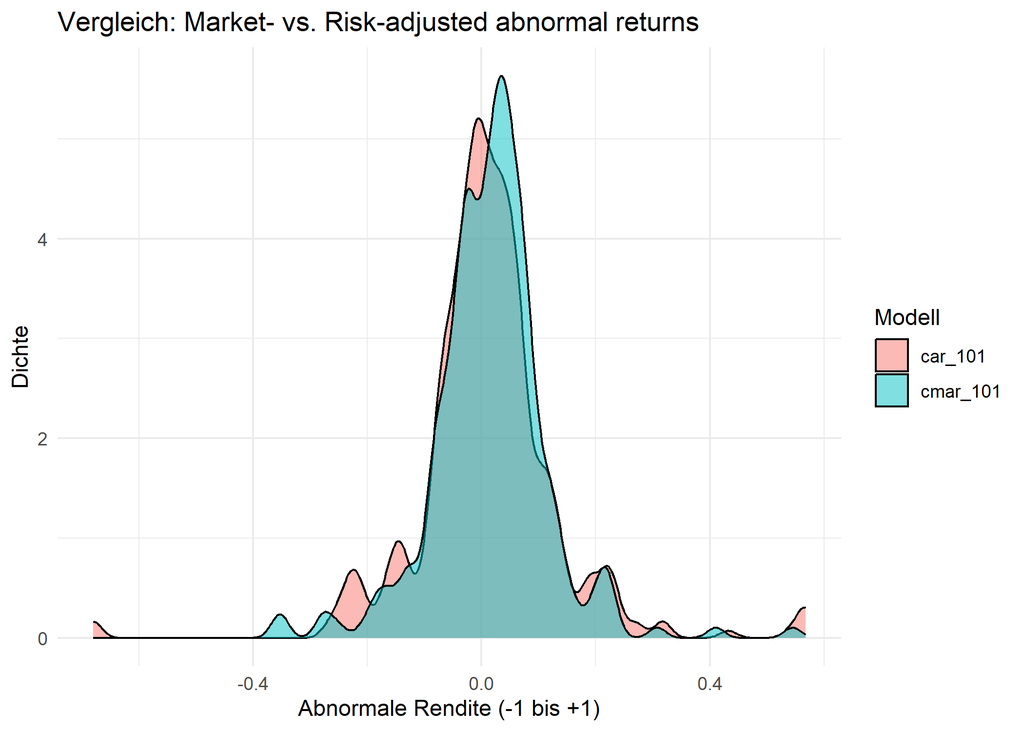

**Beschreibung**

Beide Verteilungen weisen einen deutlichen Schwerpunkt im Bereich um 0 auf, was zeigt, dass die meisten abnormalen Renditen rund um Earnings Conference Calls nahe am erwarteten Wert liegen. Die Verteilungen sind relativ schmal und nur wenige Beobachtungen liegen im extremen negativen oder positiven Bereich. Die Flächen der beiden Modelle überlappen stark, wobei kleine Unterschiede vor allem in den Randbereichen auffallen – etwa gibt es bei `car_101` geringfügig mehr extreme Werte, während `cmar_101` tendenziell eine höhere Dichte direkt um den Mittelwert aufweist. Insgesamt ist die Verteilung der risk-adjusted abnormal returns (`cmar_101`) leicht zentrierter und glatter, während die market-adjusted returns (`car_101`) etwas ausgeprägtere Ausreißer haben.

**Interpretation**

Die zentrale Frage lautet, ob es große Unterschiede zwischen den beiden Modellen gibt und wie diese zu erklären sind. Die Grafik macht deutlich: Die Verteilungen der abnormalen Renditen unterscheiden sich nur geringfügig. Beide Ansätze führen zu sehr ähnlichen Ergebnissen bezüglich der Marktreaktion auf Earnings Conference Calls im Zeitraum -1 bis +1 Tagen. Das risk-adjusted Modell (`cmar_101`) liefert im Vergleich eine minimal schmalere, symmetrischere Verteilung und scheint weniger Ausreißer zu generieren. Dies deutet darauf hin, dass durch die Risikoadjustierung (also die individuelle Schätzung von `alpha` und `beta` für jedes Unternehmen) systematische Unterschiede in der Sensitivität der Einzelaktien gegenüber dem Gesamtmarkt besser herausgefiltert werden können als beim einfachen Marktmodell (`car_101`).

Warum gibt es (nur) geringe Unterschiede? Der wichtigste Grund ist, dass viele große europäische Technologieunternehmen im Sample eine relativ konstante Beziehung zum Markt aufweisen und keine starken individuellen Abweichungen. Dadurch erklärt das einfache Marktmodell (`car_101`) bereits einen Großteil der zu erwartenden Rendite, und der Mehrwert des risk-adjusted Models (`cmar_101`) bleibt gering. Die Risikoadjustierung greift vor allem dann, wenn einzelne Unternehmen deutlich unterschiedlich auf den Markt reagieren oder ihre `beta`-Werte stark vom Durchschnitt abweichen. In der Realität des betrachteten Datensatzes sind diese Unterschiede offenbar eher gering.

Insgesamt zeigt sich: Für diesen Datensatz und das betrachtete Zeitfenster reicht das einfache Marktmodell (`car_101`) bereits aus, um die abnormalen Renditen rund um Earnings Conference Calls realistisch abzubilden. Die Hinzunahme eines risk-adjusted Modells (`cmar_101`) erhöht die Präzision, führt aber nicht zu grundlegend anderen Ergebnissen. Das spricht für eine robuste Marktintegration der Unternehmen im `Euro Stoxx 600 Technology Index` und eine weitgehend homogene Reaktion der Aktienkurse auf Earnings Calls.

19. Erstellen Sie die Grafik von Aufgabe 12 neu.

Beschreiben und interpretieren Sie ihre Grafik. Gehen Sie auch auf folgende Fragen ein:

- Könnte es zu Problemen führen, wenn in der Schätzperiode vor dem Event ein weiterer Earnings-Conference Call enthalten ist?
  - Warum könnte dies ein Problem sein, oder warum nicht?

*Nachtrag zur Aufgabe 19 seitens des Dozenten*

“Sie sollten stattdessen die Grafiken aus Aufgabe 14 mit den in Aufgabe 18 neu berechneten abnormalen Renditen des Risk-adjusted returns models neu erstellen.”

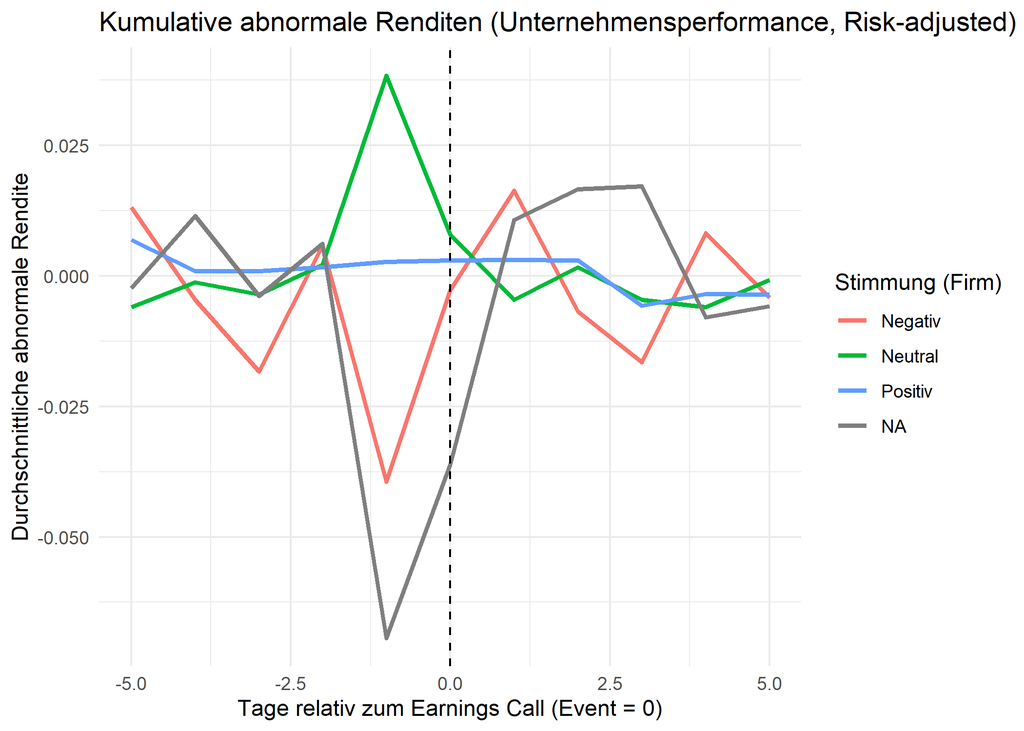

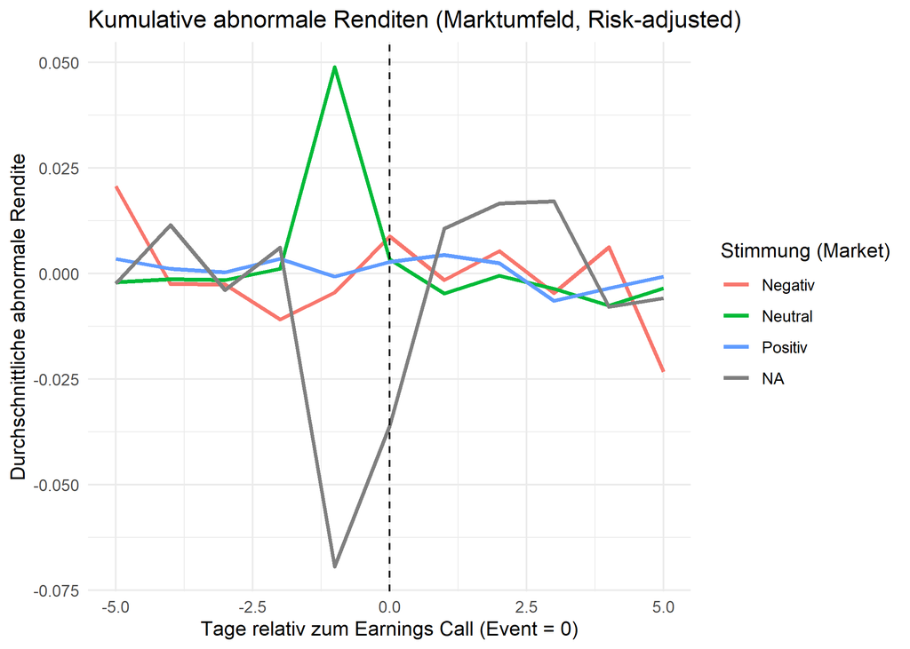

**Beschreibung**

Die beiden präsentierten Liniendiagramme zeigen die durchschnittlichen kumulierten abnormalen Renditen im Zeitraum von fünf Tagen vor bis fünf Tage nach einem Earnings Conference Call (ECC), basierend auf dem sogenannten Risk-adjusted Returns Model. Die erste Grafik bezieht sich auf das Sentiment bezüglich der Unternehmensperformance, während die zweite das Sentiment zum Marktumfeld abbildet. Die x-Achse zeigt die Tage relativ zum Event (Tag 0 = Earnings Call), die y-Achse die durchschnittliche abnormale Rendite. In beiden Grafiken sind die Linien nach Stimmungsgruppen aufgeteilt: negativ, neutral und positiv, jeweils basierend auf der Sentiment-Bewertung der Earnings Calls.

**Interpretation**

Ein kritischer Punkt bei der Berechnung der abnormalen Renditen mit dem Risk-adjusted Model ist die Wahl der Schätzperiode. Hierbei könnten Probleme auftreten, wenn innerhalb dieser Periode ein weiterer Earnings Conference Call stattgefunden hat. In diesem Fall würde die Schätzung der „normalen“ Aktienperformance bereits die Effekte des vorherigen Calls beinhalten – die Benchmark wäre dann verzerrt, weil nicht mehr von einer informationslosen, „normalen“ Periode ausgegangen werden kann. Das Modell würde die Erwartungsrendite unterschätzen oder überschätzen, was wiederum die abnormalen Renditen verzerren könnte. Gerade bei Unternehmen mit häufigen Calls oder weiteren wichtigen Ereignissen in der Schätzperiode sollte daher geprüft werden, ob diese die Schätzung beeinflussen.

Zusammengefasst zeigen die Grafiken, dass Eventstudien mit sauber definierter Schätzperiode und sinnvoll ausgewähltem Modell aussagekräftige Ergebnisse liefern können. Für eine valide Kausalschätzung ist jedoch besonders wichtig, dass die Schätzperiode frei von weiteren relevanten Events ist und das Modell die Renditeentwicklung korrekt abbildet. In der Praxis bleibt diese Anforderung eine zentrale methodische Herausforderung.

20. Lesen Sie das Kapitel [“Fixed Effects” in Huntington-Klein (2021)](https://theeffectbook.net/ch-FixedEffects.html#how-does-it-work), speziell Kapitel 16.1
21. Regressieren Sie die `cmar_101` auf die Variablen *negativ_firm* und *negativ_market* und kontrollieren Sie auf die Größe des jeweiligen Unternehmens, indem Sie die Variable *Total_Assets* in ihre Regression aufnehmen. Kontrollieren Sie weiterhin auf das Jahr in dem das Event stattgefunden hat. Fügen Sie weiterhin der Regression Firmen-Fixe Effekte hinzu.

Beschreiben und interpretieren Sie ihre Ergebnisse.

Gehen Sie zusätzlich auf die folgenden Frage ein:

- Was sind Firmen-Fixe Effekte und warum könnten diese für ihre Regression sinnvoll sein?

*Hinweis:* Mit dem [Paket `fixest`](https://cran.r-project.org/web/packages/fixest/vignettes/fixest_walkthrough.html) und der Funktion feols() können Sie einfach ihren Regressionen fixe Effekte hinzufügen

|  | cmar_101 |
| --- | --- |
| negativ_firm | 0.022 |
|  | (1.293) |
| negativ_market | 0.000 |
|  | (0.026) |
| log_assets | -0.072* |
|  | (-2.910) * |
| Num.Obs. | 1586 |
| R2 | 0.126 |
| R2 Within | 0.032 |
| Std.Errors | by: Jahr |

**Beschreibung**

Die dargestellte Tabelle zeigt die Ergebnisse einer linearen Regression, in der die abhängige Variable `cmar_101` ist. Diese steht für die kumulierte abnormale Rendite im Zeitraum von -1 bis +1 Tagen um einen Earnings Conference Call, berechnet mit dem risk-adjusted returns model. Als erklärende Variablen gehen das negative Sentiment auf Firmenebene (`negativ_firm`), das negative Sentiment auf Marktebene (`negativ_market`) sowie die logarithmierte Unternehmensgröße (`log_assets`) ein. Darüber hinaus werden sogenannte Firmen-Fixe Effekte (`firm_id`) und Jahres-Fixe Effekte (`Jahr`) berücksichtigt.

**Interpretation**

Die wichtigsten Erkenntnisse dieser Regression betreffen die Rolle der Unternehmensgröße und die Kontrolle für sogenannte Fixe Effekte. Besonders die Unternehmensgröße (`log_assets`) zeigt einen signifikanten negativen Effekt auf die abnormalen Renditen. Das legt nahe, dass größere Unternehmen weniger stark auf Earnings Conference Calls reagieren, vermutlich weil bei diesen Unternehmen die Informationslage insgesamt transparenter und stabiler ist. Die Dummyvariablen für das negative Sentiment (`negativ_firm` und `negativ_market`) zeigen keine statistisch signifikanten Effekte, was dafür spricht, dass – nach Kontrolle für unternehmens- und jahresspezifische Unterschiede – das Sentiment allein keine eigenständige Erklärungskraft mehr besitzt.

Ein zentraler Aspekt dieser Analyse sind die Firmen-Fixe Effekte (`firm_id`). Dabei handelt es sich um eine Methode, mit der für alle zeitinvarianten, unternehmensspezifischen Charakteristika kontrolliert wird. Das heißt, jedes Unternehmen bekommt im Regressionsmodell einen eigenen Mittelwert (Intercept), sodass alle Vergleiche **innerhalb** der Unternehmen über die Zeit erfolgen und **zwischen** den Unternehmen systematische Unterschiede (wie Branche, Managementstil oder Bilanzpolitik) herausgerechnet werden. So wird sichergestellt, dass der geschätzte Einfluss von Sentiment oder Unternehmensgröße nicht durch unbeobachtete, konstante Unterschiede zwischen Unternehmen verzerrt wird.

Gerade im Kontext von Earnings Conference Calls ist diese Methode sinnvoll: Unternehmen unterscheiden sich dauerhaft hinsichtlich Risikoprofil, Medienpräsenz, Analystenabdeckung oder Markterwartungen. Ohne Firmen-Fixe Effekte könnten diese Unterschiede fälschlicherweise als Effekt des Sentiments erscheinen. Fixe Effekte machen die Schätzung robuster gegenüber omitted variable bias, sofern die Unterschiede über die Zeit konstant sind.

Zusammengefasst zeigen die Ergebnisse, dass das Sentiment – nach Berücksichtigung von Jahres- (`Jahr`) und Firmen-Fixeffekten (`firm_id`) – keinen signifikanten Einfluss mehr auf die abnormalen Renditen hat, während Unternehmensgröße weiterhin eine Rolle spielt. Die Berücksichtigung von Fixen Effekten ist daher ein wichtiger methodischer Schritt, um wirklich kausale Effekte zu identifizieren und nicht lediglich Korrelationen zwischen unternehmensspezifischen Merkmalen und den Renditen.

**Was sind Firmen-Fixe Effekte und warum könnten diese für die Regression sinnvoll sein?**

Firmen-Fixe Effekte (auch „Fixed Effects“ genannt, hier: `firm_id`) sind Kontrollvariablen, die für jedes Unternehmen einen eigenen Basiswert (Intercept) im Regressionsmodell festlegen. Sie helfen, unbeobachtete, konstante Unterschiede zwischen den Unternehmen zu eliminieren und sorgen dafür, dass die Schätzung der übrigen Variablen nur auf **innerhalb** eines Unternehmens über die Zeit basierenden Schwankungen basiert. Das ist insbesondere dann wichtig, wenn Unternehmen sich systematisch voneinander unterscheiden, was im Fall von börsennotierten Firmen mit unterschiedlichsten Geschäftsmodellen und Marktumfeldern der Fall ist. Nur so können Kausaleffekte, die tatsächlich durch kurzfristige Veränderungen wie ein Earnings Conference Call ausgelöst werden, korrekt identifiziert werden. Das macht die Regression deutlich belastbarer und die Ergebnisse relevanter für die Beantwortung der Forschungsfrage.

# Literatur

- Kapitel Event Studies im Buch [The Effect Book: Event Studies](https://theeffectbook.net/ch-EventStudies.html)
- Kapitel Fixe Effekte im Buch [The Effect Book: Event Studies](https://theeffectbook.net/ch-FixedEffects.html)
- [Paket `fixest`](https://cran.r-project.org/web/packages/fixest/vignettes/fixest_walkthrough.html)

# Anhang

## Prompt Arten

Prompt-Arten unterscheiden sich in der Anzahl der Beispiele, die Sie dem KI-Modell geben:

**Zero-Shot Prompt**

- Keine Beispiele gegeben
- Nur die Aufgabe wird beschrieben
- Beispiel: “Übersetze ins Englische: Guten Morgen”

**One-Shot Prompt**

- Ein einziges Beispiel wird gezeigt
- Das Modell lernt aus diesem einen Beispiel
- Beispiel: “Übersetze ins Englische:

Guten Tag → Good day Guten Morgen → ?”

**Few-Shot Prompt**

- Mehrere Beispiele werden gegeben (typisch 2-5)
- Das Modell kann aus mehreren Mustern lernen
- Beispiel: “Übersetze ins Englische:

Guten Tag → Good day Auf Wiedersehen → Goodbye Danke → Thank you Guten Morgen → ?”